# Data Visualization Group Project: How Financial Markets Reacted to the Pandemic

Study Group 5: Etra Bianco, Vasu Dev Puri, Himanshu Singh, Yi Yan Ng, Mengze Sun, Christian Gonder

2020-12-03

# 1 Introduction

The Covid-19 pandemic is an unprecedented crisis challenging the lives and livelihoods of billions of people around the globe. As an indicator of the economic cycle, Study Group 5 analysed the impact of the Covid19 pandemic on stock markets in major economies. The purpose of this analysis was to understand how the current economic crisis is different from previous shocks, both in its magnitiude and its recovery, as well as the underlying reasons.

**Methodology** Our Datasets - Financial markets data: Downloaded from CapitalIQ, Bloomberg - Covid data: John Hopkins University Covid19 database - Background reading: Financial Times, The Economist and further research

**Process** - Data Collection - Inspecting, Cleaning and Exploring Data - Problem definition and scope clarification - Deep-Dive into subsections, e.g. drop, recovery, industry break-down - Model-building and visualizing findings

Before get into our story we ICE the data below.

# 2 Loading and Investigating the data

```r
#Loading the data

indeces <- read_excel("Data/indices_data.xls")
```

```r
#Having a first look at what the data includes
head(indeces)
#Using the summary functions to have a more general idea about what is in the data
glimpse(indeces)
#Using the describe function for more detailed information about data.
describe(indeces)
```

# 3 Cleaning the data

To clean the data we need to check: - duplicates - missing values (NAs) - empty values - cross column consistency

## 3.1 Cleaning column names

We first shorten the names of the columns in our data frame. Moreover, we run the clean names function to remove capital letters and add underscores to separate words.

```r
#Copying the data into a new data frame we can process
originalData_process <- indeces


#we shorten the names of our variables (columns)
originalData_process <- originalData_process %>%
  rename(c("FTSE100" = 'FTSE 100 Index (^UKX) - Index Value', "S&P500" = 'S&P 500 (^SPX) - Index Value',"BSE Sensex" = "S&P BSE Sensex (^SENSEX) - Index Value",  "DAX" = 'Germany DAX Index (Performance) (^DAX) - Index Value'), "SSE" = "Shanghai Stock Exchange Composite Index (^000001) - Index Value", "TOPIX" = "TOPIX INDEX (^TOPIX) - Index Value","PX" = "Paris CAC 40 Index (^PX1) - Index Value","Euronext" = "Euronext 150 Index - Index Value")

#cleaning the variable names
originalData_process<-clean_names(originalData_process)
```

## 3.2 Initial data cleaning

Before we start looking at the contents of the data we remove empty columns and rows and want to remove duplicates if any.

```r
#Removing empty columns and rows
originalData_process<-remove_empty(originalData_process, which = c("rows","cols"))


#Checking for duplicates
dupes<-originalData_process%>%get_dupes(dates)
```

## 3.3 Missing data

As evident from the below, we have several missing values across the different indexes throughout our data frame, however, for the most part, these are on days where the stock exchange is closed eg. New Years (01/01) and other bank holidays and hence we can ignore them and proceed.

```r
#chekcing for nas accross the columns
nas <- sapply(originalData_process , function(x) sum(is.na(x)))
data.frame(nas) %>%
  arrange(desc(nas)) %>%
  rename('Number of NAa' = 'nas') %>%
  kbl() %>%
  kable_styling()
```

|  | Number of NAa |
| --- | --- |
| topix | 333 |
| euronext | 287 |
| sse | 264 |
| bse_sensex | 210 |
| s_p500 | 198 |
| ftse100 | 165 |
| dax | 106 |
| px | 89 |
| dates | 0 |

# 4 The Story

This study aims to present the findings of how COVID19 has impacted the economy as well as the stock market. For the past year in 2020, the economy has been hit by the covid pandemic, affecting numerous industries and sectors. Different parts of the world have been affected at varying levels, with the number of cases climbing quickly in certain regions. Although China was the first country to detect virus, it has performed well throughout the pandemic and was able to control the situation very quickly, resulting in a low number of cases per 100k population. Countries such as the US for example, has much larger number of cases per 100k population, showing a large disparity in the impact of covid.

## 4.1 COVID World map

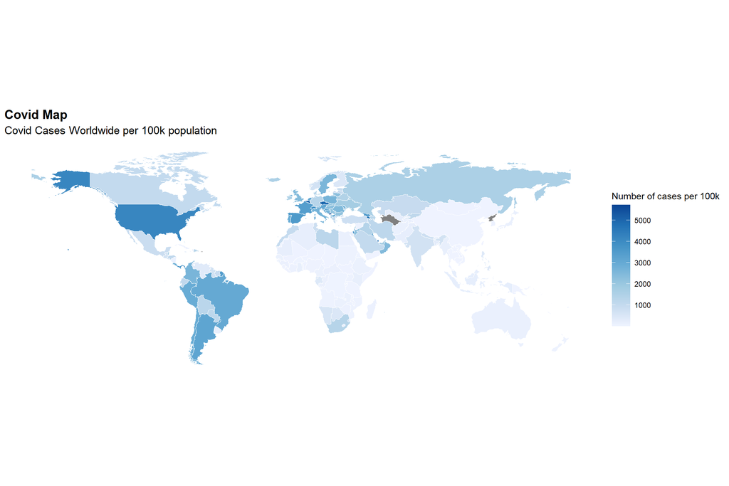

```r
#extracting populatuion
library(wpp2019)

#get 2020 pop and country code
data(pop)
pop_2020 <- pop %>%
  select(c(1,17)) %>%
  mutate(`2020` = `2020` * 1000)

#importing covid and cleaning data set
covid_1 <- read_csv('data/covid_jh.csv')
covid_1<- clean_names(covid_1)

#extracting only the final columns
covid <- covid_1[-1 ,c(319:320)] %>%
  rename('iso_a3' = 'iso_3166_1_alpha_3_codes') %>%
  group_by(iso_a3) %>%
  summarise(total = sum(x12_1_20))



#getting geometrty and isocodes
earth <- ne_countries(scale = 50, returnclass = "sf") %>%
  select(admin, geometry, iso_a3)



#getting geometrty and isocodes
iso_un <- ne_countries(scale = 50, returnclass = "sf") %>%
   select(iso_a3  , un_a3 , iso_n3  ) %>%
   mutate(un_a3 = as.integer(un_a3) , iso_n3 = as.integer(iso_n3))



#joinning 2020 pop and country code with geometry together
 map_100k <- left_join(pop_2020, iso_un , by = c('country_code' = 'iso_n3')) %>%
   filter(is.na(iso_a3) == FALSE) %>%
   select(`2020`, iso_a3, geometry) %>%
   left_join(covid %>%
   select(iso_a3 , total) , by = 'iso_a3') %>%
  mutate(cases_per100 = (total/`2020`)*1e5)



#converting to geographic data base
map_100k <- map_100k %>%
  sf::st_as_sf()


options(scipen = 999)

#making map showing cases per 100K population worldwide
map_100k  %>%
  ggplot() +
  geom_sf(aes(fill = cases_per100), size = 0.1, color = "white") +
  coord_sf(crs = "+proj=longlat" , datum = NA) +
  scale_fill_distiller( palette = "Blues",
                    direction = 1 ,
                    guide = guide_colorbar(
                      title = "Number of cases per 100k",
                      title.hjust = 0.5,
                      labels = unit_format(unit = "K", scale = 1e-3) ,
                      direction = "vertical",
                      nrow = 1,
                      keyheight = unit(3, units = "mm"),
                      keywidth = unit(3, units = "mm"),
                      title.position = "top"  ,
                      barheight =  10 , barwidth = 1.5)) +
  theme_minimal() +
  theme(legend.direction = "horizontal",
        legend.position = "right" ,
        panel.grid.major.y = element_blank() , panel.grid.minor.y = element_blank(),  plot.title = element_text(size = 15, face= "bold"), plot.subtitle = element_text(size = 13)) +
  labs(title = "Covid Map",
       subtitle = "Covid Cases Worldwide per 100k population")
```

## 4.2 Timeline of all the indices

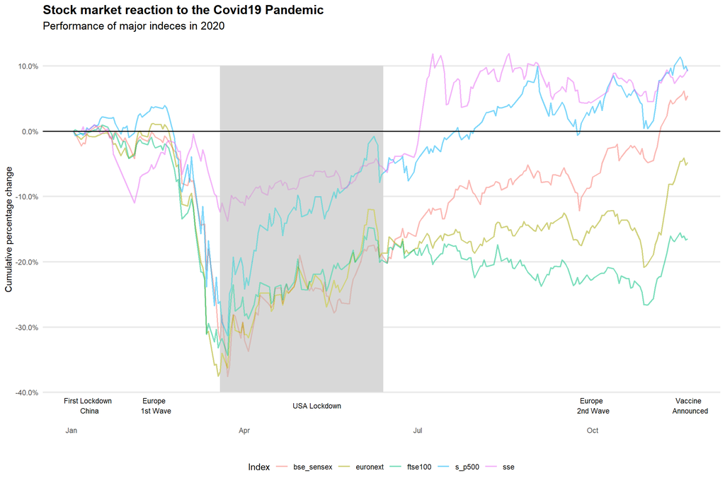

```r
### USA , ftse , germany during covid
#limit data to 2020 jan, feb march
early_covid <- originalData_process %>%
  filter(year(dates) == 2020 )

#removing first row which is new years
early_covid <- early_covid[-1,]


#transforming each column to a percentage change from initial value
for (i in c(2:9)){
inital_val <- unlist(early_covid[1,i[[1]]])
early_covid[,i] <- (early_covid[ ,i]/inital_val)- 1

}

#creating data frame for cross correlation
ccf_df <- early_covid %>%
  select(`sse`, `ftse100`, `s_p500`, `euronext`, `bse_sensex` )




#removing any nas
early_covid <- early_covid %>%
  pivot_longer( cols = c(`sse`, `ftse100`, `s_p500`, `euronext`, `bse_sensex` ), names_to = 'market' , values_to = 'pct_change') %>%
  filter(is.na(pct_change) == FALSE)


# plot
plot_3 <- ggplot(early_covid) +
  geom_line(aes(x = dates, y=pct_change, color = market) , size = .8 , alpha = 0.5) +
   geom_rect(aes(xmin= as.POSIXct(as.Date(c("2020-03-19"))) , xmax  = as.POSIXct(as.Date(c("2020-06-13"))),
         ymin = -0.4 , ymax = 0.1) , alpha = 0.002) +
  geom_hline(yintercept = 0 , size = 0.6 ) +
  scale_y_continuous(labels =  scales::percent) +
  theme_minimal() +
  theme(panel.grid.major.x =  element_blank() ,
        panel.grid.minor =  element_blank() ,
        panel.grid.major.y = element_line(size = 1),
        legend.position = 'bottom') +
  labs(y = 'Cumulative percentage change' , x = '' ) +
  theme(plot.title = element_text(size = 15, face= "bold"), plot.subtitle = element_text(size = 13)) +
  labs(title = "Stock market reaction to the Covid19 Pandemic",
       subtitle = "Performance of major indeces in 2020" , color = 'Index')+

  #adding annotation of the main time of the epidemic
  annotate("text", x = as.POSIXct(as.Date(c("2020-01-10","2020-02-14","2020-05-09","2020-10-01", "2020-11-21"))),
           y = c(-0.42, -0.42,-0.42,-0.42,-0.42),
           label = c("First Lockdown \n China", "Europe \n 1st Wave","USA Lockdown","Europe \n 2nd Wave", "Vaccine \n Announced"),
           color="black", size=3 , angle=0)



plot_3
```

### 4.2.1 Cross Correlation Matrix

```r
#correlation matrix for the various indices.
cols_1 = character()
cols_2 = character()
corr_list = double()


#creating  a data framw wiht correlatin scores
i = 1
for (col1 in colnames(ccf_df)){
  j = 1
  for (col2 in colnames(ccf_df)){

 #calculating the cross correlation for the two columns
ccf_values = ccf(ccf_df[rowSums(is.na(ccf_df[, i]))  == 0,i] , ccf_df[rowSums(is.na(ccf_df[, j]))  == 0,j] , plot = FALSE)

#calculating the values
values = ccf_values[0][[1]][[1]]

#appending the values
cols_1[[length(cols_1) + 1]] = col1
cols_2[[length(cols_2) + 1]] = col2
corr_list[[length(corr_list) + 1]] = values

j = j+1
  }
i = i +1
}
```

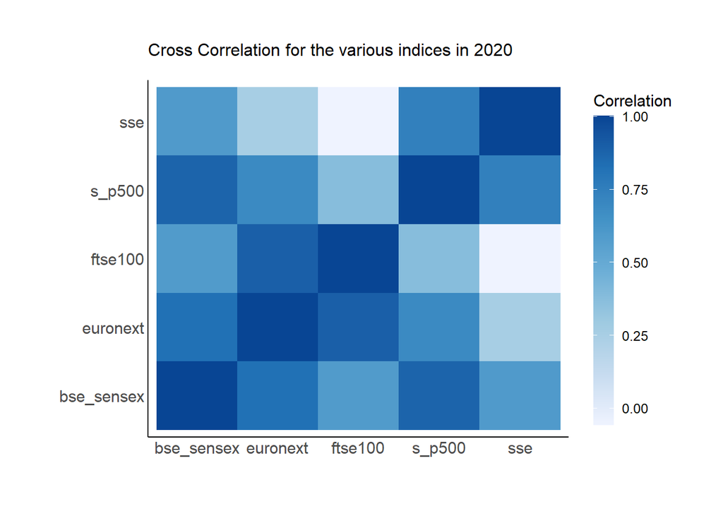

```r
#making correlation heatmap
plot_4 <-data.frame(cbind(cols_1 ,cols_2 , corr_list))%>%
  ggplot() +
    geom_tile(aes(x  = cols_1 , y = cols_2 , fill = as.double(corr_list))) +
   scale_fill_distiller(palette = "Blues" ,
                        direction = 1) +
  labs(x = '' , y = ' '  ) +
  guides(fill =  guide_colourbar(title = 'Correlation' , barheight = 15 , barwidth = 1))+
  #adjusting the theme
  theme_ipsum() +
    theme(panel.grid.minor = element_blank() , panel.grid.major = element_blank()) +
  theme( axis.line = element_line(), panel.grid.major = element_blank() , panel.grid.minor= element_blank(),
         plot.title = element_text(size = 15, face= "bold"), plot.subtitle = element_text(size = 12) ,
         ) +
  labs(
       subtitle = "Cross Correlation for the various indices in 2020 ")

plot_4
```

## 4.3 volatility vs Drop

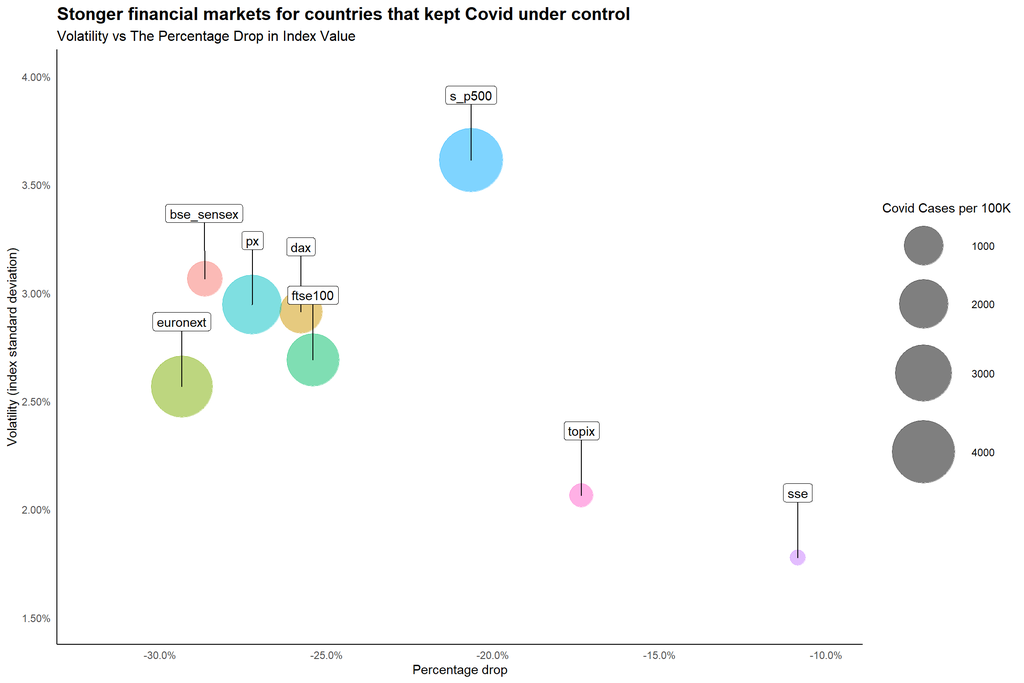

```r
# loading original dataframe to a new one to make graphs
bubble_df <- originalData_process

# identifying dataframe to make bubble plot
 plot_df2 <- bubble_df %>%
  filter(month(dates) %in% c(1,2,3)) %>%
  filter(year(dates) == 2020) %>%
  pivot_longer(cols = c(2:9),  names_to = 'market' , values_to = 'price' ) %>%
  filter(is.na(price) == FALSE) %>%
  group_by(market) %>%
   # We use the following calculation method to show volatity
  mutate(per_change = (price/lag(price))  - 1) %>%
  summarise(.groups = "keep" , first_val = first(price) , last_val = last(price) , std = sd(per_change , na.rm = TRUE)) %>%
  mutate(perc_drop =(last_val/first_val ) - 1) %>%
  select(market, perc_drop , std , last_val)

# adding covid cases to illustrate the size of bubbles
  plot_df2$covidcases =c(685.708, 1306.549, 3740.9595, 2420.36, 3403.425, 4145.376, 6.01331, 119.37083 )


# making the plot showing Volatility vs The Percentage Drop in Index Value.
# the size of the bubble means the number of cases.
plot_2 <- plot_df2 %>%
  ggplot() +
  geom_point(aes(x = perc_drop , y = std , size = covidcases,  color = market) , alpha = 0.5) +
  theme_minimal() +
  scale_size(range = c(6,25)) +
  # geom_label_repel(mapping = aes(x = perc_drop , y = std ,  label = market) ,
  #                  force = 20 , direction = "both" , face = 'bold' , )+
  # geom_label(mapping = aes(x = perc_drop , y = std ,  label = market , fill = market)
  #            , direction = "both" , face = 'bold' ,nudge_x = 0,
  # nudge_y = 0.003, )+
   geom_label_repel(mapping = aes(x = perc_drop , y = std ,  label = market )
             , direction = "both" , face = 'bold' ,nudge_x = 0,
  nudge_y = 0.003, )+
  scale_x_continuous(labels = scales::percent ,limits = c(-0.32, -0.1) ) +
  scale_y_continuous(labels = scales::percent,limits = c(0.015, 0.04)) +
  theme(legend.position =  'bottom') +
   guides(color=guide_legend("market"), fill = FALSE) +
  theme_minimal() +
  theme( axis.line = element_line(), panel.grid.major = element_blank() , panel.grid.minor= element_blank(),
         plot.title = element_text(size = 15, face= "bold"), plot.subtitle = element_text(size = 12) ,
         ) +
  labs(title = "Stonger financial markets for countries that kept Covid under control",
       subtitle = "Volatility vs The Percentage Drop in Index Value ",
       y = "Volatility (index standard deviation)", x = "Percentage drop" ,
       size = 'Covid Cases per 100K')  +guides(colour=FALSE)


plot_2
```

## 4.4 Comparing negative quarters for each market

```r
library(scales)
library(zoo)
#creating the percentage drops for each quarters
quarters <- originalData_process %>%
  mutate(quarter = quarter(dates) , year = year(dates) , q_y = paste0(quarter, '/' , year)) %>%
pivot_longer( cols = c(`sse`, `ftse100`, `s_p500`, `euronext`, `bse_sensex` , `topix`), names_to = 'market' , values_to = 'price')%>%
  filter(is.na(price) == FALSE) %>%
  #groupby quarter and market
  group_by(year, q_y, market) %>%
  #finding first and last value
  summarise(first_val = first(price)  , last_val = last(price) , first_day = min(as.Date(dates))) %>%
  #calculating the percentage drop
  mutate(perc = (last_val/first_val)  - 1)%>%
  #keeping only negative
  filter(perc < -0.08)

df <- quarters %>%
  pivot_wider(id_cols = c(`q_y` , `market`, `perc`) , names_from = 'market' , values_from= 'perc')



#creating a top 10 quarters for each index
df_new <- data.frame()
for (col in colnames(df[,-1])) {
print(col)
temp_df <- df[is.na(df[,col]) == FALSE, col]
#extract covid
last_val <- last(temp_df)
#get second last value
i_final <- nrow(temp_df)-1
#remove covid vaue
temp_df <- temp_df[1: i_final ,]
#sort by top 9
temp_df <- temp_df[order(temp_df[col] , decreasing =  FALSE)[1:9] , ]
#add covid
temp_df[10, col] <- last_val

df_new <- append(temp_df , df_new)
}
```

```
## [1] "topix"
## [1] "bse_sensex"
## [1] "euronext"
## [1] "s_p500"
## [1] "ftse100"
## [1] "sse"
```

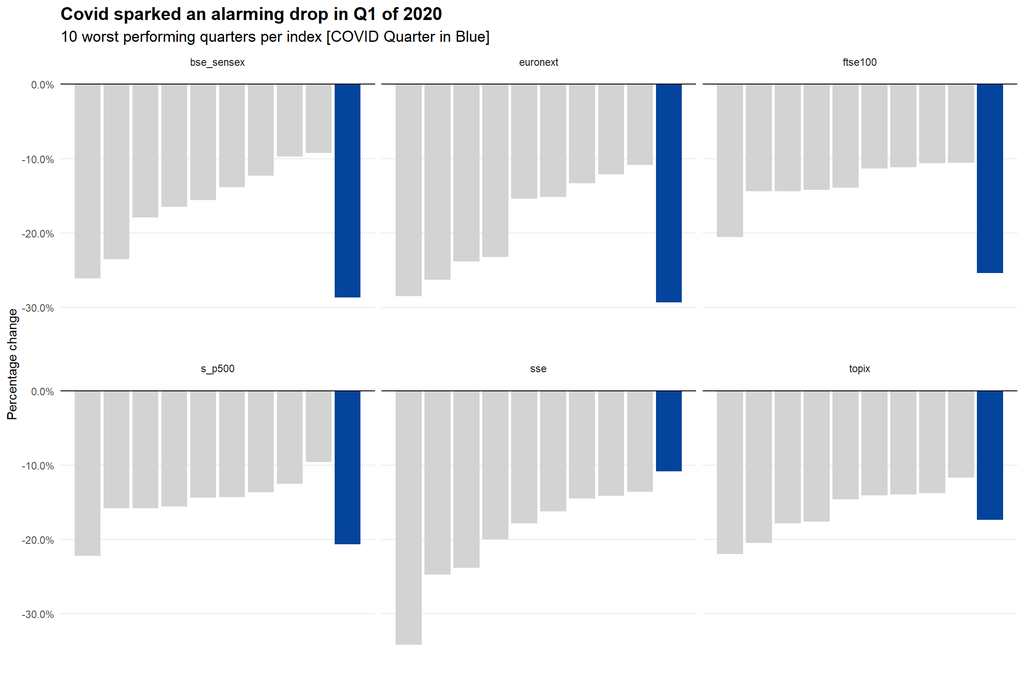

```r
df_new$index <- c(1:10)

df_new$fill_box <- c('no_color', 'no_color', 'no_color', 'no_color' ,'no_color' , 'no_color' ,'no_color', 'no_color' , 'no_color' , 'COVID')



#plotting bar chart
plot_1 <- data.frame(df_new) %>%
  pivot_longer(c(1:6) , names_to = 'market' , values_to  = 'perc' ) %>%
  ggplot() +
  geom_col(aes(x = index, y = perc, fill = fill_box))+
  facet_wrap(.~market)+
theme_minimal() +
  geom_hline(yintercept = 0)+
  scale_fill_manual(values=c("#04449c","light grey")) +
  theme(panel.grid.minor = element_blank() ,
        panel.grid.major.x  = element_blank(),
        legend.position = 'bottom' , axis.ticks.x = element_blank()) +
  scale_y_continuous(label = scales::percent)  +
  labs (title = "Covid sparked an alarming drop in Q1 of 2020",
  subtitle = "10 worst performing quarters per index [COVID Quarter in Blue]",
       x = "",
  y = "Percentage change") +
    theme(plot.title = element_text(size = 15, face= "bold"), plot.subtitle = element_text(size = 13) ,
          axis.ticks.x = element_blank() , axis.text.x =  element_blank()) +
  guides(fill = FALSE)


plot_1
```

## 4.5 The Aggregate vs S&P performance throughout the year

During the data exploration phase, we noted that major indices of the world mirror the S&P 500. Hence, we chose to focus on the S&P 500 solely. Within US as well, we had to be selective when choosing which indices to incorporate. For example, we made the conscious decision to include the S&P 500 over the DOW Jones / NASDAQ as it was a better-balanced index due to varied constituents from different sectors.

```r
#chekcing for total number rows wiht na values
originalData_process[rowSums(is.na(originalData_process[, -1])) > 0,]
```

```
## # A tibble: 1,114 x 9
##    dates                 dax   sse bse_sensex ftse100 s_p500 topix euronext
##    <dttm>              <dbl> <dbl>      <dbl>   <dbl>  <dbl> <dbl>    <dbl>
##  1 2000-01-03 00:00:00 6751. 1367.      5375.   6930.  1455.   NA        NA
##  2 2000-01-04 00:00:00 6587. 1406.      5491.   6666.  1399. 1717.       NA
##  3 2000-01-05 00:00:00 6502. 1410.      5357    6536.  1402. 1652.       NA
##  4 2000-01-06 00:00:00 6475. 1464.      5422.   6447.  1403. 1610.       NA
##  5 2000-01-07 00:00:00 6781. 1517.      5414.   6505.  1441. 1599.       NA
##  6 2000-01-10 00:00:00 6926. 1545.      5518.   6608.  1458.   NA        NA
##  7 2000-01-11 00:00:00 6891. 1480.      5296.   6519.  1439. 1679.       NA
##  8 2000-01-12 00:00:00 6913. 1438.      5491.   6533.  1432. 1657.       NA
##  9 2000-01-13 00:00:00 6956. 1424.      5445.   6531.  1450. 1658.       NA
## 10 2000-01-14 00:00:00 7173. 1409.      5471.   6658.  1465. 1648.       NA
## # ... with 1,104 more rows, and 1 more variable: px <dbl>
```

```r
#total of 11114 rows which is ~20% so could use the prevous datts
originalData_process[rowSums(is.na(originalData_process[, -1])) > 0 ,] %>%
  filter(year(dates) == 2020)
```

```
## # A tibble: 49 x 9
##    dates                  dax   sse bse_sensex ftse100 s_p500 topix euronext
##    <dttm>               <dbl> <dbl>      <dbl>   <dbl>  <dbl> <dbl>    <dbl>
##  1 2020-01-01 00:00:00    NA    NA      41306.     NA     NA    NA       NA
##  2 2020-01-02 00:00:00 13386. 3085.     41627.   7604.  3258.   NA     2929.
##  3 2020-01-03 00:00:00 13219. 3084.     41465.   7622.  3235.   NA     2915.
##  4 2020-01-13 00:00:00 13452. 3116.     41860.   7618.  3288.   NA     2903.
##  5 2020-01-20 00:00:00 13549. 3096.     41529.   7651.    NA  1744.    2922.
##  6 2020-01-24 00:00:00 13577.   NA      41613.   7586.  3295. 1730.    2873.
##  7 2020-01-27 00:00:00 13205.   NA      41155.   7412.  3244. 1703.    2818.
##  8 2020-01-28 00:00:00 13324.   NA      40967.   7481.  3276. 1692.    2838.
##  9 2020-01-29 00:00:00 13345    NA      41199.   7484.  3273. 1700.    2854.
## 10 2020-01-30 00:00:00 13157.   NA      40914.   7382.  3284. 1675.    2823.
## # ... with 39 more rows, and 1 more variable: px <dbl>
```

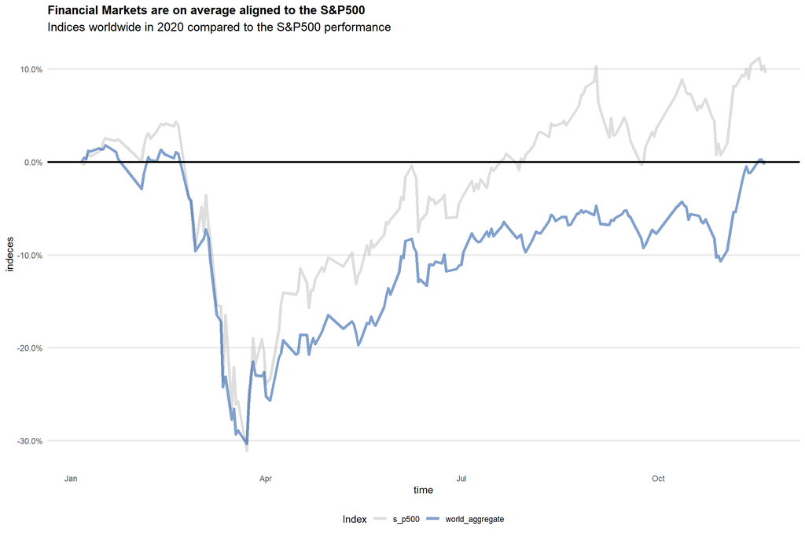

```r
#for 2020 reduced to 50 which is 50/240
full_year_2020 <- originalData_process[!rowSums(is.na(originalData_process[, -1])) > 0 ,] %>%
  filter(year(dates) == 2020)

#transforming each column to a percentage change from initial value
for (i in c(2:9)){
inital_val <- unlist(full_year_2020[1,i[[1]]])
full_year_2020[,i] <- (full_year_2020[ ,i]/inital_val)- 1

}


#getting the avereage perforrmance of all indices
full_year_2020$world_aggregate <- rowSums(full_year_2020[, -1])/8


#plotting the graph
plot_5 <- full_year_2020 %>%
  select(dates, s_p500 , world_aggregate) %>%
  pivot_longer(cols = 2:3 , names_to ='market' , values_to = 'pct_change' ) %>%
  ggplot() +
  geom_line(aes(x = dates, y=pct_change, color = market) , size = 1.5 , alpha = 0.5) +
  geom_hline(yintercept = 0 , size = 1 ) +
  scale_y_continuous(labels =  scales::percent) +
  scale_color_manual(values = c('grey' , '#04449c'))+
  theme_minimal() +
  theme(panel.grid.major.x =  element_blank() ,
        panel.grid.minor =  element_blank() ,
        panel.grid.major.y = element_line(size = 1),
        legend.position = 'bottom') +
  labs (subtitle = "Indices worldwide in 2020 compared to the S&P500 performance",
  title = "Financial Markets are on average aligned to the S&P500",
       x = "time",
  y = "indeces" ,
  color = 'Index') +
    theme(panel.background =element_blank(),
         panel.grid.major  = element_blank() ,
         panel.grid.minor = element_blank(),
         axis.ticks.x = element_blank(),
         axis.ticks.y = element_blank(),
         plot.title = element_text(size = 13, face= "bold"), plot.subtitle = element_text(size = 13))
plot_5
```

## 4.6 Money Supply graph

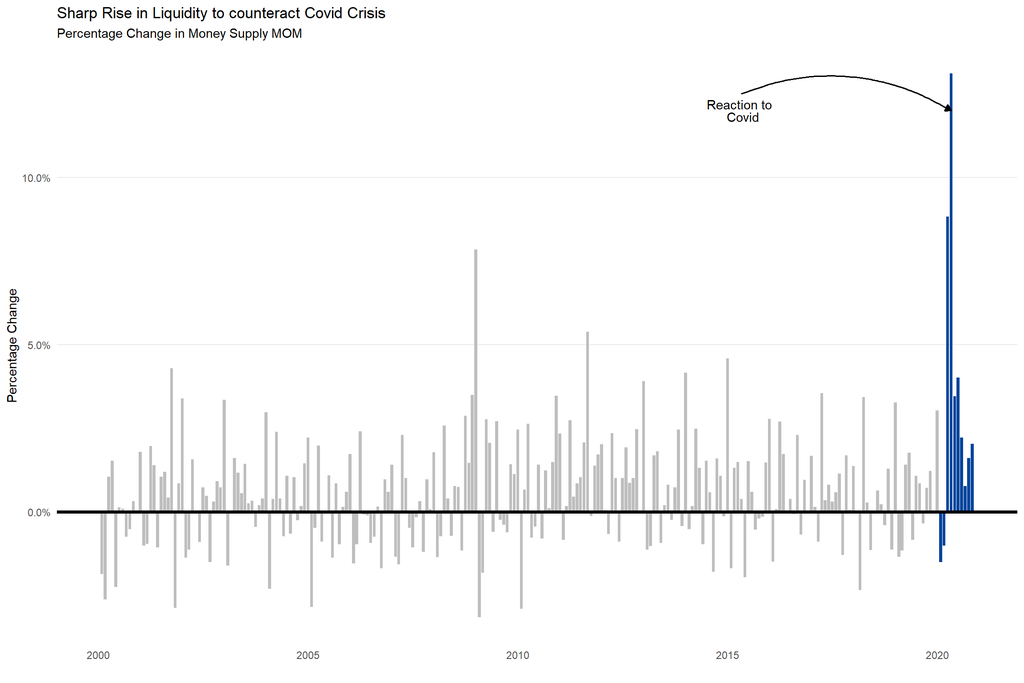

```r
#importing the money supply graph
money_supp <- read_xlsx('Data/Money Supply M.xlsx')
money_supp <- clean_names(money_supp)

#adding a covid columns
money_supp <- money_supp %>%
  mutate(covid_time = ifelse(year(name) == 2020  , 'Yes' ,'No' ))

library(scales)

#ploting the bar chart

plot_6 <- money_supp %>%
  ggplot() +
  geom_col(aes(x = name , y = usa_m1_mo_m/100 , fill = covid_time )) +
  labs(
    y = 'Percentage Change' ,
    x= '' ,
    subtitle = 'Percentage Change in Money Supply MOM' ,
    title = 'Sharp Rise in Liquidity to counteract Covid Crisis'

  ) +
  theme_minimal() +
  scale_y_continuous(labels = scales::percent) +
  theme(panel.grid.minor = element_blank() ,
        panel.grid.major.x = element_blank(),
        legend.position = 'none') +
  scale_fill_manual(values = c('grey' , '#04449c'))+
  geom_hline(yintercept =  0 , size = 1.3) +
  geom_text(
    data = data.frame(x = as.POSIXct(as.Date(c("2015-04-30"))), y = 0.12, label = "Reaction to \n Covid"),
    aes(x = x, y = y, label = label),
    colour="black",
    family="Lato",
    hjust = 0.5,
    lineheight = .8,
    inherit.aes = FALSE,
  ) +


  geom_curve(
    data = data.frame(x =as.POSIXct(as.Date(c("2015-04-30"))) , y = 0.125, xend = as.POSIXct(as.Date(c("2020-04-30"))), yend = 0.12),
    mapping = aes(x = x, y = y, xend = xend, yend = yend),
    colour = "black",
    size = 0.6,
    curvature = -0.25,
    arrow = arrow(length = unit(2, "mm"), type = "closed"),
    inherit.aes = FALSE
  )
plot_6
```

## 4.7 Drawdown

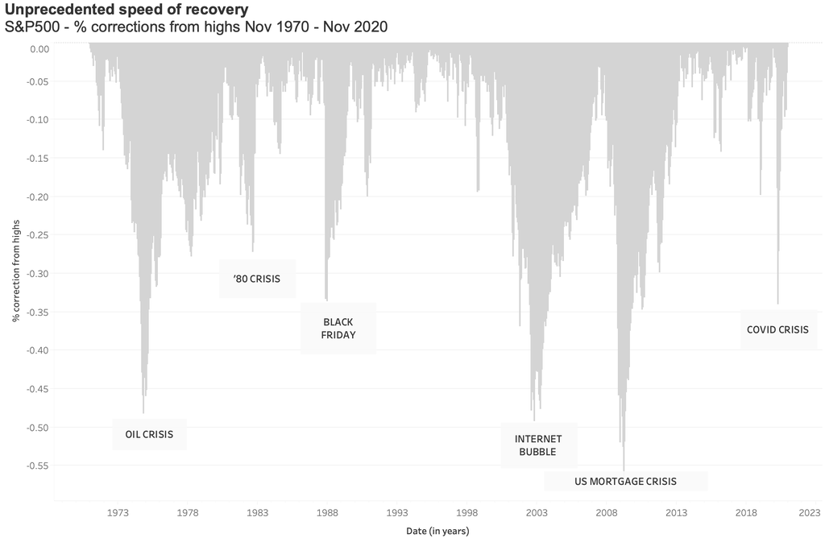

S&P500-% correction from highs

## 4.8 Composition Changes for USA Stock Market

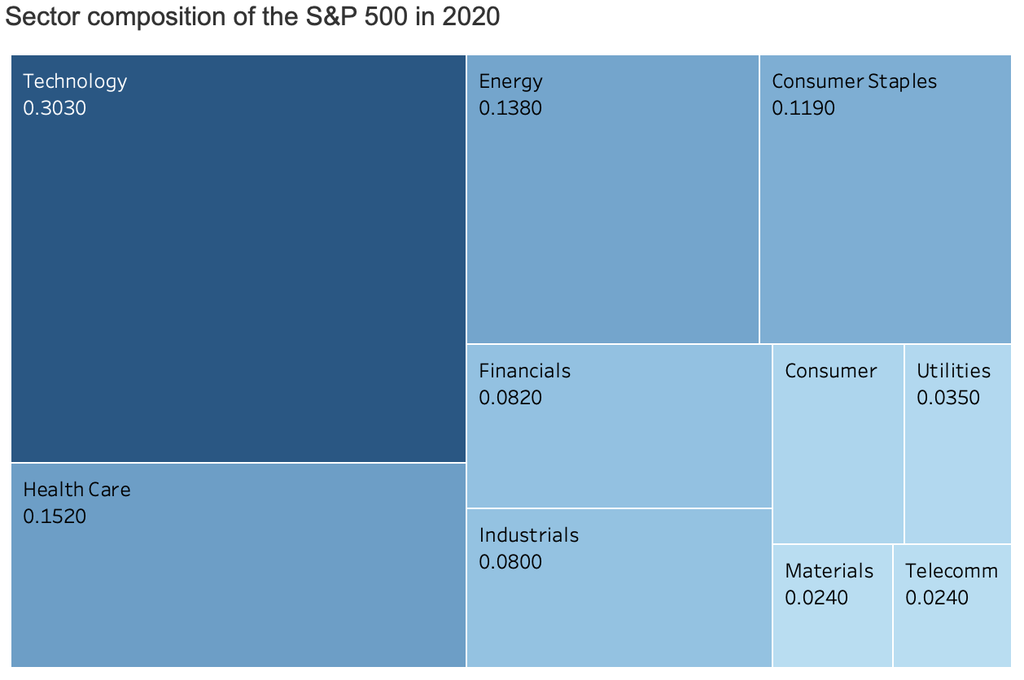

Sector composition of the S&P 500

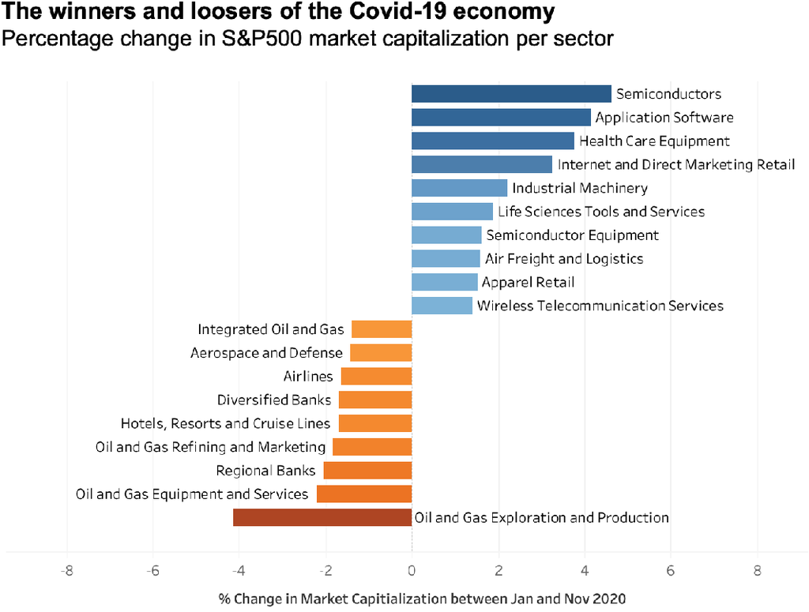

Percentage change in S&P500 market capitalization per sector

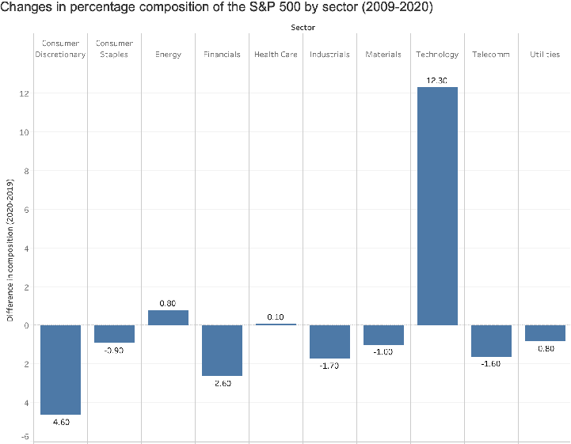

Changes in percentage composition of the S&P500 by sector

## 4.9 Sentiment Analysis

```r
#Loading Data
data<-read.csv("Data/scores/scores.csv")
fed_data <- read.csv("Data/fed_sent.txt")


#Using mean of each month
graphdata<-data%>% mutate(date=as.Date(date)) %>%
  mutate(month=month(date)) %>%
  group_by(month)%>%
  summarise(neg = mean(neg),
            neu = mean(neu),
            pos = mean(pos),
            comp = mean(compound))%>%
  ungroup() %>%
  pivot_longer(c(neg,neu,pos,comp),names_to="type",values_to="score")
graphdata
```

```
## # A tibble: 44 x 3
##    month type   score
##    <int> <chr>  <dbl>
##  1     1 neg    0.125
##  2     1 neu    0.766
##  3     1 pos    0.109
##  4     1 comp  -0.264
##  5     2 neg    0.119
##  6     2 neu    0.768
##  7     2 pos    0.113
##  8     2 comp  -0.157
##  9     3 neg    0.107
## 10     3 neu    0.765
## # ... with 34 more rows
```

```r
# meanscores<-fed_data %>%   group_by(year) %>%  summarize(neg = mean(neg))
# meanscores

#making dataframe to a frame that easy to plot
fed_data_long <-fed_data %>%
  pivot_longer(c(neg,neu,pos,comp),names_to="type",values_to="score")
```

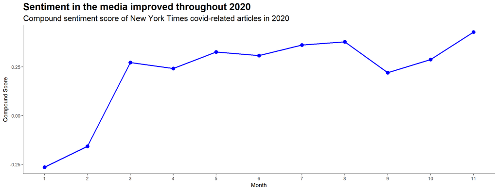

```r
#graphing sentiment score of New York Times in 2020
graphdata[graphdata$type=="comp" ,]%>% ggplot(aes(y = score,x=month,col=type))+
  geom_line(color="blue",size=1) +
   geom_point(color="blue",size=3)+
   labs(title="Sentiment in the media improved throughout 2020",
          subtitle="Compound sentiment score of New York Times covid-related articles in 2020",
        y="Compound Score", x = "Month")+
   scale_x_continuous(breaks=seq(12))+
   theme(
   plot.title = element_text(size = 18, face= "bold"), plot.subtitle = element_text(size = 15),
   panel.grid.major= element_blank(),
   axis.line = element_line(colour = "#555555"),
   panel.grid.minor= element_blank(),
   panel.background = element_blank()
   )
```

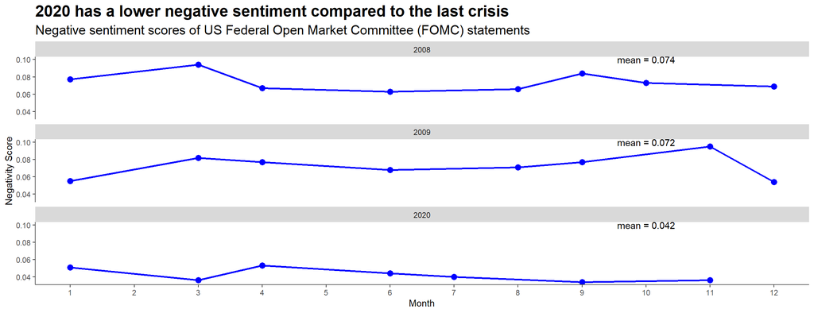

```r
#graphing the the sentiment scores during main crisis.
graph<-fed_data_long[fed_data_long$type=="neg",]%>% ggplot(aes(y = score,x=month))+
  geom_line(color="blue",size=1) +
   geom_point(color="blue",size=3)+
  facet_wrap(~year,nrow=3)+
   labs(title="2020 has a lower negative sentiment compared to the last crisis",
        subtitle = "Negative sentiment scores of US Federal Open Market Committee (FOMC) statements",
        y="Negativity Score", x = "Month")+
   scale_x_continuous(breaks=seq(12))+
   theme(
   plot.title = element_text(size = 18, face= "bold"), plot.subtitle = element_text(size = 15),
   panel.grid.major= element_blank(),
   axis.line = element_line(colour = "#555555"),
   panel.grid.minor= element_blank(),
   panel.background = element_blank()
   )

dat_text <- data.frame(
  label = c("mean = 0.074","mean = 0.072","mean = 0.042"),
  year   = c(2008,2009,2020)
)

graph+   geom_text(data=dat_text,
                    mapping = aes(x =10, y = 0.1, label = label)
)
```

Overall, the media sentiment for COVID has an increasing trend through the year, presenting a positive outlook for recovery. This is also mirrored in the sentiment of federal statements from the US Federal Open Market Committee for the economic and financial policies.

Compared to the last crisis, in particular the recession in 2008/2009, COVID has had a much faster economic recovery. The statements in 2020 had much less negative statements compared to those released in 2008 and 2009, as shown in the graph. During the previous crisis, although there were policies and agreements rolled out to support the economy, there was still a large amount of uncertainty in regards to economic outlook which resulted in more negative sentiment overall. The average negative sentiment score for 2020 was 0.042 which was significantly lower than the year 2008 which had a score of 0.074 in comparison.

# 5 Conclusion

While Covid19 spread dissimilarity across countries, financial markets reacted in unison to the 2020 recession. However, the evolution of the market has been different across geographies as, for example, effective crisis management facilitated the recovery for come countries. Moreover, interestingly, the recovery from the 2020 recession followed a V-shape and was faster than in previous downturns. In narrowing down our focus on the factors that contributed to the recovery we looked at the USA specifically and found that the growth of the technology sector within the S&P500 largely contributed to the quick recovery in the financial markets. Another aspect that we investigated was the sentiment of financial institutions and the media regarding the pandemic, as this can influence confidence levels in the economy and have wide-reaching implications. From our sentiment analysis we noted a relatively lower negativity in the statements by the US Federal Reserve when compared to those released during the crisis of 2008 and also noted an increase in positivity in the media. We thus conclude that the high share of technology, the relatively favourable sentiment and the high liquidity in the market have contributed to a speedy recovery.

**Discussion & Critique**

- Vast research topic: Finding the focus was challenging.
- Further indices & index-specific deep dives could have been relevant and insightful.For example, included the S&P 500 over the DOW Jones / NASDAQ as it was a better-balanced index due to varied constituents from different sectors. However, this is also a limiting condition since we did not conduct the same level of data exploration on other indices